# RNA seq workflow part 2 - Dimensionality redution and PCA plot

HIOs dual seq experiment 2

Ryan Berger

2018-08-07

# 1 Purpose

This script is part of a workflow for RNA seq processing and analysis (modified from [Bioconductor](https://www.bioconductor.org/help/workflows/rnaseqGene/)). The purpose is to take in a DESeq2 object (dds) and return a PCA plot of all the samples.

# 2 Begin script

## 2.1 Libraries and directories

```r
# #+ load_pkgs, error=T
library(DESeq2)
library(ggplot2)
library(knitr)
library(magrittr)
library(rmarkdown)
source(here("src/Hs_align_src/ggplot2-themes.R"))
```

The output files will go to the `DESeq2_human` folder in the results directory.

```r
results.dir <- here('results/DESeq2_human/')
```

## 2.2 Load the data

We previously saved the `dds` object in the results folder. Let’s load it now:

```r
dds <- readRDS(here('results/DESeq2_human/dds_all.rds'))
```

## 2.3 Transform data using rlog

Before running PCA, we’ll do an rlog transformation of the data. This is a variance stabilizing transformation that “transforms the count data to the log2 scale in a way which minimizes differences between samples for rows with small counts, and which normalizes with respect to library size” ([source](https://rdrr.io/bioc/DESeq2/man/rlog.html)).

```r
rld <- rlog(dds, blind = FALSE)
```

```
## rlog() may take a few minutes with 30 or more samples,
## vst() is a much faster transformation
```

```r
# Compare before and after transformation
head(assay(dds)[,1:4], 3) ; head(assay(rld)[,1:4], 3)
```

```
##      PBS_2h-1 PBS_2h-2 PBS_2h-3 PBS_2h-4
## 7SK     67903    39853    61157    60511
## A1BG       63       70       68       58
## A1CF      463      309      601      498
```

```
##       PBS_2h-1  PBS_2h-2  PBS_2h-3  PBS_2h-4
## 7SK  15.629999 15.510858 15.663343 15.520041
## A1BG  5.844764  6.173564  6.124059  5.824177
## A1CF  8.400030  8.532529  8.966631  8.767614
```

```r
# Save the rlog transformed data
saveRDS(rld, file = file.path(results.dir, 'rld_all.rds'))

# Load the rlog transformed data
rld <- readRDS(here('results/DESeq2_human/rld_all.rds'))
```

## 2.4 PCA plot

Now we can run PCA using the `plotPCA` function from DESeq2 and use those values to make a custom plot with `ggplot`. First we’ll set the order of injection to how we want it to show up in the plot.

```r
# Set order of injection
unique(colData(rld)$Inject)
```

```
## [1] PBS  STM  ST   SE   SPI1 SPI2
## Levels: PBS SE SPI1 SPI2 ST STM
```

```r
colData(rld)$Inject <- colData(rld)$Inject %>%
  factor(., levels(.)[c(1,6,2,5,3,4)])
```

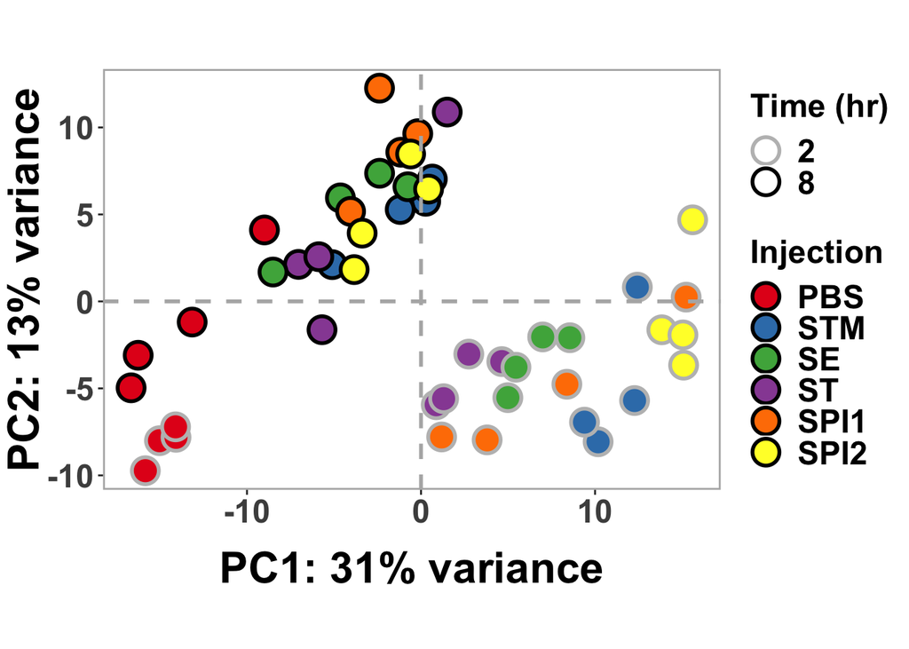

```r
# PCA plot (use just only for PC variance estimates)
pca <- plotPCA(rld, intgroup = c('code_name','Inject','hr'))

# Get PCA data
pca.df <- plotPCA(rld, intgroup = c('code_name', 'Inject', 'hr'), returnData = TRUE)


# Make plot
plot <- ggplot(data = pca.df, aes(x = PC1, y = PC2))+
  geom_point(shape = 21, stroke = 1.5,
             aes(fill = as.factor(Inject),
                 color = as.factor(hr)),
             size = 6) +
  theme1 +
  #scale_y_continuous(limits = c(-25,25), breaks = seq(-25, 25, by = 10)) +
  scale_fill_brewer(palette = "Set1", name = 'Injection') +
  #scale_color_brewer(palette = "Set2", name = 'Time', direction = 1) +
  scale_color_manual(values=c("gray", "black"), name = 'Time (hr)')+
  theme(legend.position = "right") +
  geom_hline(yintercept = 0,
             size = 1, linetype = "dashed", color = "grey70") +
  geom_vline(xintercept = 0,
             size = 1, linetype = "dashed", color = "grey70") +
  coord_fixed(ratio = 1) +
  xlab(pca$labels$x) + #pull variance estimates from al. plotPCA call
  ylab(pca$labels$y) +
  # Move y axis
  theme(axis.title.y = element_text(margin = margin(t = 0, r = 1,
                                                    b = 0, l = 0))) +
  # Move x axis
  theme(axis.title.x = element_text(margin = margin(t = 10, r = 0,
                                                    b = 0, l = 0)))+
 # Shrink axis labels down
  theme(plot.caption = element_text(vjust = 1),
    axis.title = element_text(size = 24),
    axis.text.x = element_text(size = 18),
    axis.text.y = element_text(size = 18),
    plot.title = element_text(size = 30))

plot
```

## 2.5 Observations

Looking at the PCA plot, it appears the main sources of variance are the time point of collection and the presence/absence of bacteria injected. This seems to separate samples into an interesting pattern of three clusters:

- The bottom left of the plot shows the PBS controls at both 2 and 8 hours clustering together and showing separation from all the HIOs injected with bacteria (except for one control that is in the upper left quadrant).
- The upper middle of the plot shows all of the 8 hour bacterially injected HIOs clustering together.
  - For the most part, it looks like 3 of 4 samples for each subtype of bacteria are grouped together while one sample shows more variance.
- The bottom right of the plot is where all the 2 hour HIOs injected with bacteria are clustering together.

PC1 contains 31% of the total variance and splits samples by PBS control, 8 hour infected samples, and 2 hour infected samples. Interestingly, there appears to be greater variance from PBS control after 2 hours of exposure to bacteria than at 8 hours.

PC2 seems to mostly split the 8 hour infected samples from the PBS control and 2 hour infected samples.

## 2.6 Save plot

We’ll save the PCA plot as a .png file in the `img` directory.

```r
# save png of plot
```

```r
png(filename = here("/img/pca.png"),
    width = 900, height = 500)
print(plot)
dev.off()
```